# 20 Generalized linear model

Tobias Gerstenberg

3/1/2019

> The lecture is pretty clear in illustrating the concepts of lmer models. But I think, in the future, you may want to make use of some mathematical equations to clearly illustrate how the model can remove “random intercept”, “correlations between random effects” and etc. This is because I still find it difficult to wrap my head around for all these concepts by simply looking at the lmer model syntax, instead of the read equations. Thanks!

> Really liked the class. I thought the visualizations of the tumor data were super helpful.

> Might have been helpful to explain what “converging” meant before explaining what to do about it. Otherwise, this was great!

## Student feedback

|  | response |
| --- | --- |
| 1 | Tobi is so amazing that he even counted to infinity... Twice. |
| 2 | The lecture is pretty clear in illustrating the concepts of lmer models. But I think, in the future, you may want to make use of some mathematical equations to clearly illustrate how the model can rem… |
| 3 | GLM seems GREAT. Really excited about this. Titanic examples were perfect. Great class. |
| 4 | Just a quick thank you for investing so much time into the class slides, R scripts, and resources. I know this doesn't really get rewarded career-wise here but I've had a number of conversations with … |
| 5 | Really liked the class. I thought the visualizations of the tumor data were super helpful. |
| 6 | Might have been helpful to explain what "converging" meant before explaining what to do about it. Otherwise, this was great! |
| 7 | Thank you for a great class! |
| 8 | do we use glm only with the categorical DVs? |
| 9 | "the three biggest wizarding schools in Europe: Durmstrang, Beauxbatons and Hogwarts." :) https://www.pottermore.com/features/triwizard-tournament-retrospective |

### PollEverywhere results

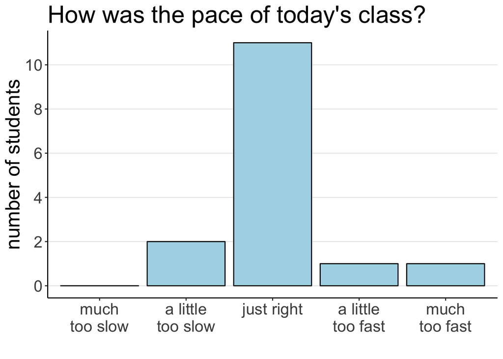

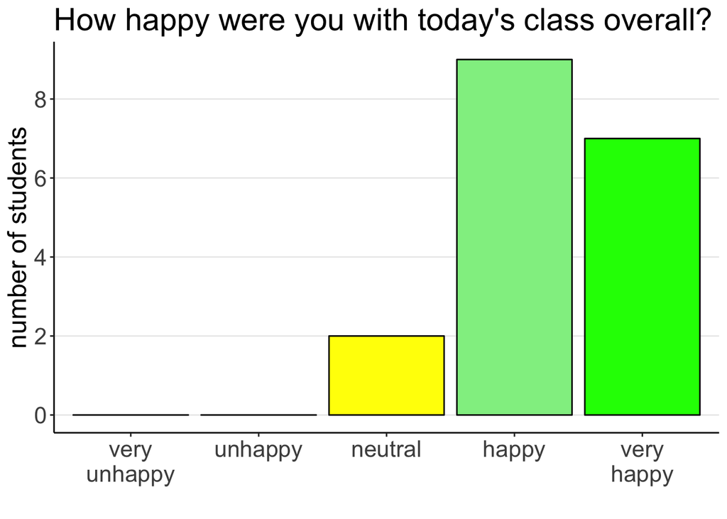

## Homework 5

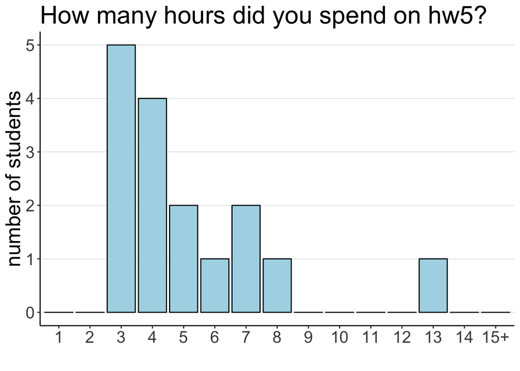

## What to do next time

- make sure to explain what “converging” means before talking about what to do about it if the model doesn’t converge
- the explanation of nested vs. crossed models can be improved
- figure out whether it’s possible to have interactions in the random effects structure
- the Titanic data set is good for illustrating logistic regression
- the visualization demo at the beginning helped
- maybe: talk a little more about how to interpret odds
- managed to get until slide 63 (before “Fitting and reporting models”)